# Project 3 - Example Main Script

Grp 1

Oct 21, 2017

```r
if(!require("EBImage")){
  source("https://bioconductor.org/biocLite.R")
  biocLite("EBImage")
}
## OBS - add more packages here
if(!require("gbm")){
  install.packages("gbm")
}
## OBS - add more packages here
library("EBImage")
library("gbm")
library("MASS")
library("OpenImageR")
library("jpeg")
```

### Step 0: specify directories.

# here replace it with your own path or manually set it in RStudio to where this rmd file is located.

```r
setwd("/Users/pedrohmariani/Documents/Columbia/Academic/Fall 2017/AppliedDataScience/Projects/TZstatsFolder/Fall2017-project3-fall2017-project3-grp1/doc")
#setwd("~/Desktop/Fall2017-project3-fall2017-project3-grp1-master/doc")
```

```r
experiment_dir <- "../data/training_set/" # This will be modified for different data sets.
img_train_dir <- paste(experiment_dir, "train/", sep="")
img_test_dir <- paste(experiment_dir, "test/", sep="")
```

### Step 1: set up controls for evaluation experiments.

In this chunk, ,we have a set of controls for the evaluation experiments.

- (T/F) cross-validation on the training set
- (number) K, the number of CV folds
- (T/F) process features for training set
- (T/F) run evaluation on an independent test set
- (T/F) process features for test set

```r
run.cv = T # run cross-validation on the training set
K <- 5  # number of CV folds
run.feature.train = TRUE # process features for training set
run.test = TRUE # run evaluation on an independent test set
run.feature.test = TRUE # process features for test set

# Boolean variables for Feature Extraction
run.pca = FALSE #Performs PCA dimensionality reduction on images
run.hogs = TRUE
run.cnn = FALSE
run.lbp = FALSE

# Boolean variables for running model
run.gbm = FALSE
run.svm = TRUE
run.rf = FALSE
run.lda = FALSE
```

# OBS

## Add stuff here to call different models

```r
model_values<-seq(0.01,0.25,0.05) #for GBM
#model_labels = paste("GBM with shrinkage value =", model_values) # for GBM

svm_gamma_values <- seq(0, 0.5, by = 0.1)
svm_gamma_labels = paste("SVM gamma =", svm_gamma_values) # for SVM

rf_par = expand.grid(mtry = seq(5,15),ntree = seq(1000,2500,500)) #for RF
```

### Step 2: import training images class labels.

```r
label_train <- read.csv("../data/training_set/label_train.csv", header=T)
```

### Step 3: construct visual feature

```r
source("../lib/feature - final.R")

tm_feature_train <- NA
if(run.feature.train){
  tm_feature_train <- system.time(dat_train <- feature(img_train_dir,
                                                       n_pixel_row = 20,
                                                       n_pixel_col = 320,
                                                       n_dig = 4,
                                                       n_hogs = 54,
                                                       desired_variance = 0.9,
                                                       run.pca = run.pca,
                                                       run.hogs = run.hogs,
                                                       run.cnn = run.cnn,
                                                       run.lbp = run.lbp,
                                                       export=TRUE) )
}

tm_feature_test <- NA
if(run.feature.test){
  tm_feature_test <- system.time(dat_test <- feature(img_test_dir,
                                                       n_pixel_row = 20,
                                                       n_pixel_col = 20,
                                                       n_dig = 4,
                                                       n_hogs = 54,
                                                       desired_variance = 0.9,
                                                       run.pca = run.pca,
                                                       run.hogs = run.hogs,
                                                       run.cnn = run.cnn,
                                                       run.lbp = run.lbp,
                                                       export=TRUE) )
}

save(dat_train, file="../output/feature_train.RData")
save(dat_test, file="../output/feature_test.RData")
```

### Step 4: Train a classification model with training images

Call the train model and test model from library.

`train.R` and `test.R` should be wrappers for all your model training steps and your classification/prediction steps. + `train.R` + Input: a path that points to the training set features. + Input: an R object of training sample labels. + Output: an RData file that contains trained classifiers in the forms of R objects: models/settings/links to external trained configurations. + `test.R` + Input: a path that points to the test set features. + Input: an R object that contains a trained classifier. + Output: an R object of class label predictions on the test set. If there are multiple classifiers under evaluation, there should be multiple sets of label predictions.

```r
source("../lib/train - final.R")
source("../lib/test - final.R")

load("../output/feature_train.RData")
load("../output/feature_test.RData")
```

#### Model selection with cross-validation

```r
source("../lib/cross_validation.R")
baseline_dat_train <- read.csv("../data/training_set/sift_train.csv", header=T)
baseline_dat_train<-baseline_dat_train[,-1]

cv.svm = T
cv.gbm = F
cv.rf = F
cv.lda = F

if(run.cv) {

  if( cv.gbm ){
    err_cv <- array(dim=c(length(model_values), 2))

    for(k in 1:length(model_values)){
      cat("k=", k, "\n")
      err_cv[k,] <- cv.function( as.data.frame(dat_train), label_train, model_values[k], K, cv.gbm = T)
      #err_cv[k,]<-cv.function(baseline_dat_train,label_train,model_values[k],K,cv.gbm = T)
     }
  }

  if( cv.svm ){

  err_cv <- array(dim=c(length(svm_gamma_values), 2))

   for(k in 1:length(svm_gamma_values)){
    cat("k=", k, "\n")
     err_cv[k,] <- cv.function( dat_train, label_train, d = svm_gamma_values[k], K = K, cv.svm = T)
   }

  }



  if( cv.rf ){
    err_cv <- array(dim=c(nrow(rf_par), 2))
    model_values = rf_par

    for(k in 1:nrow(rf_par)){
      cat("k=", k, "\n")
      err_cv[k,] <- cv.function( dat_train, label_train, rf_par[k,], K, cv.rf = T)
    }
  }

  save(err_cv, file="../output/err_cv.RData")
}
```

```
## k= 1
## [1] "train.data:"
## [1] 2400   54
## [1] "train.data:"
## [1] 2400   54
## [1] "train.data:"
## [1] 2400   54
## [1] "train.data:"
## [1] 2400   54
## [1] "train.data:"
## [1] 2400   54
## k= 2
## [1] "train.data:"
## [1] 2400   54
## [1] "train.data:"
```

[output cut: 51 more lines]

Visualize cross-validation results.

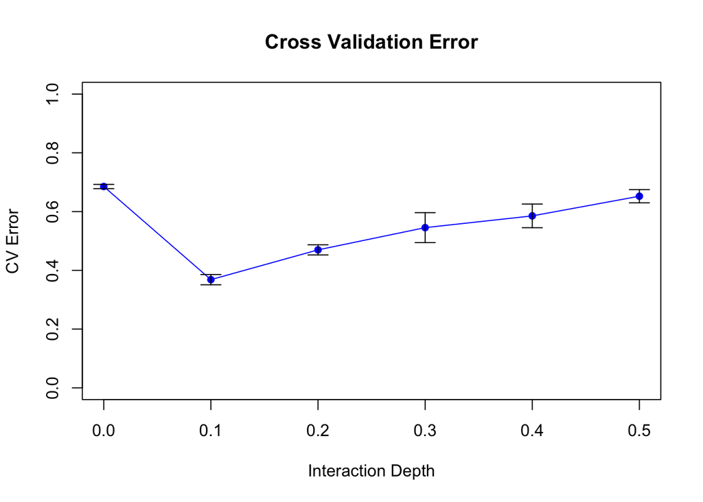

```r
if(run.cv){

  if(cv.gbm){
    load("../output/err_cv.RData")
    #pdf("../fig/cv_results.pdf", width=7, height=5)
    plot(model_values, err_cv[,1], xlab="Interaction Depth", ylab="CV Error",
         main="Cross Validation Error", type="n", ylim=c(0, 1))
    points(model_values, err_cv[,1], col="blue", pch=16)
    lines(model_values, err_cv[,1], col="blue")
    arrows(model_values, err_cv[,1]-err_cv[,2], model_values, err_cv[,1]+err_cv[,2],
    length=0.1, angle=90, code=3)
    #dev.off()
    }

  if(cv.svm){
    load("../output/err_cv.RData")
    #pdf("../fig/cv_results.pdf", width=7, height=5)
    plot(svm_gamma_values, err_cv[,1], xlab="Interaction Depth", ylab="CV Error",
         main="Cross Validation Error", type="n", ylim=c(0, 1))
    points(svm_gamma_values, err_cv[,1], col="blue", pch=16)
    lines(svm_gamma_values, err_cv[,1], col="blue")
    arrows(svm_gamma_values, err_cv[,1]-err_cv[,2], svm_gamma_values, err_cv[,1]+err_cv[,2],
    length=0.1, angle=90, code=3)

  }

}
```

- Choose the “best”" parameter value

```r
if( !run.rf ){
  model_best=model_values[1]
} else {
  model_best=model_values[1,]
}


if(run.gbm){
  model_best<- model_values[which.min(err_cv[,1])]
}
# if(run.cv){
#   model_best <- svm_gamma_values[which.min(err_cv[,1])]
# }
if(run.svm){
  model_best <- svm_gamma_values[which.min(err_cv[,1])]
}
if(run.rf){
  model_best <- rf_par[which.min(err_cv[,1]),]
}

par_best <- list(gamma=model_best)
```

- Train the model with the entire training set using the selected model (model parameter) via cross-validation.

```r
if( run.lda ){
  tm_train_lda <- system.time(model.lda <- train( dat_train, label_train, run.lda = TRUE ))
  save(model.lda, file="../output/model_lda.RData")
}

if( run.gbm ){
  tm_train_gbm <- system.time(model.gbm <- train( as.data.frame(dat_train), label_train, run.gbm = TRUE ))
  save(model.gbm, file="../output/model_gbm.RData")
}

if( run.svm ){
  tm_train_svm <- system.time(model.svm <- train( dat_train, label_train, run.svm = TRUE, params = model_best ))
  save(model.svm, file="../output/model_svm.RData")
}

if( run.rf ){
  tm_train_rf <- system.time(model.rf <- train(dat_train, label_train, model_best, run.rf = TRUE ))
  save(model.rf, file="../output/model_rf.RData")
}
```

### Step 5: Make prediction and Summarize running time

```r
cat("Total Time for constructing training features=", tm_feature_train[1], "s \n")
```

```
## Total Time for constructing training features= 131.044 s
```

```r
cat("Total Time for constructing testing features=", tm_feature_test[1], "s \n")
```

```
## Total Time for constructing testing features= 1.09 s
```

```r
if( run.lda ){
  tm_test_lda <- system.time(pred.lda <- test(model.lda, dat_test, test.lda = T))
  lda.error <- sum((pred.lda != label_train[1:10,2]))/(length(label_train[1:10,2]))
  cat("Test error =", lda.error * 100, "% \n")
  cat("Time for training model=", tm_train_lda[1], "s \n")
  cat("Time for testing model=", tm_test_lda[1], "s \n")
}

if( run.gbm ){
  tm_test_gbm <- system.time(pred.gbm <- test(model.gbm, dat_test, test.gbm = T))
  gbm.error <- sum((pred.gbm != label_train[1:10,2]))/(length(label_train[1:10,2]))
  cat("Test error =", gbm.error * 100, "% \n")
  cat("Time for training model=", tm_train_gbm[1], "s \n")
  cat("Time for testing model=", tm_test_gbm[1], "s \n")
}

if( run.svm ){
  tm_test_svm <- system.time(pred.svm <- test(model.svm, dat_test, test.svm = T))
  svm.error <- sum((pred.svm != label_train[1:10,2]))/(length(label_train[1:10,2]))
  cat("Test error =", svm.error * 100, "% \n")
  cat("Time for training model=", tm_train_svm[1], "s \n")
  cat("Time for testing model=", tm_test_svm[1], "s \n")
}
```

```
## Test error = 60 %
## Time for training model= 4.981 s
## Time for testing model= 0.01 s
```

```r
if( run.rf ){
  tm_test_rf <- system.time(pred.rf <- test(model.rf, dat_test, test.rf = T))
  rf.error <- sum((pred.rf != label_train[1:10,2]))/(length(label_train[1:10,2]))
  cat("Test error =", rf.error * 100, "% \n")
  cat("Time for training model=", tm_train_rf[1], "s \n")
  cat("Time for testing model=", tm_test_rf[1], "s \n")
}
```